# Handling Missing Data in Health Science Research

Day 2 - Part I

2022-06-23

# Missing responses in longitudinal studies

- Except in highly controlled settings, missing data in longitudinal studies are inevitable
- What are the implications for missing data?
  - Create complications for methods that require **balanced** data
  - Reduce the **precision** with which changes in the mean response over time can be estimated
  - Can introduce **bias** and lead to misleading inferences about changes in the mean response
- Statistical methods to account for missing data in correlated (longitudinal) data is still a rapidly developing field
- Usually, the missing data mechanism is not under the control of the investigators
- We make **assumptions** about the missing data mechanism
- Validity of the analysis depends on whether these assumptions hold
- We need to be **explicit** about the assumptions made regarding the reasons for missing data

## Example: Longitudinal outcomes in skin cancer study

- In the previous session, we focused on the baseline data and skin cancer count after the first year
- In this session, we will analyze the full data including follow-up skin cancer status from year 1 through year 5
- We will focus on the missing longitudinal **outcomes** rather than missing covariates
- However, the implementation of Poisson data is not well developed in the joint modeling framework
- Therefore, we will **dichotomize** the outcome to implement logistic regression
  - If $Y_{\text{orig}} = 0$ then $Y_{\text{new}} = 0$ and if $Y_{\text{orig}} > 0$ then $Y_{\text{new}} = 1$

```r
skin_data <- read.table("skin_data.txt", header = TRUE)
head(skin_data)
```

|  | ID | center | age | skin | gender | exposure | Y | treatment | year |
| --- | --- | --- | --- | --- | --- | --- | --- | --- | --- |
| 1 | 100034 | 1 | 51 | 1 | 1 | 4 | 0 | 0 | 1 |
| 2 | 100034 | 1 | 51 | 1 | 1 | 4 | 1 | 0 | 2 |
| 3 | 100034 | 1 | 51 | 1 | 1 | 4 | 1 | 0 | 3 |
| 4 | 100034 | 1 | 51 | 1 | 1 | 4 | 1 | 0 | 4 |
| 5 | 100034 | 1 | 51 | 1 | 1 | 4 | 0 | 0 | 5 |
| 6 | 100045 | 1 | 68 | 1 | 0 | 2 | 0 | 0 | 1 |

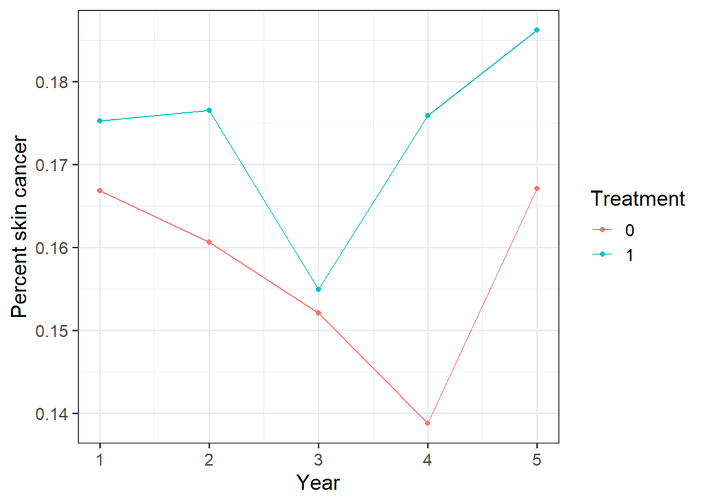

```r
skin_data <- skin_data %>%
  mutate(Y_bin = ifelse(Y == 0, 0, 1)) %>%
  dplyr::select(-Y)

## plot the data
skin_data %>%
  group_by(treatment, year) %>%
  summarise(pskin = mean(Y_bin)) %>%
  ggplot(aes(y = pskin, x = year, color = as.factor(treatment))) +
  geom_point() +
  geom_line() +
  labs(y = "Percent skin cancer", x = "Year", color = "Treatment")
```

- We are interested in modeling the population-averaged inference of the change in risk of new skin cancer by treatment group

$$\text{logit}(\mu_{ij})=\beta_{0} + \beta_{1}\text{Year}_{ij} +
\beta_{2}\text{Year}^{2}_{ij} + \beta_{4}\text{Treatment}_{i} +
\beta_{5}(\text{Year}_{ij} \times \text{Treatment}_{i})+
\beta_{6}(\text{Year}^{2}_{ij} \times \text{Treatment}_{i})$$

## Missing data notation revisted

Suppose we have $n$ repeated measurements of the same individual. Then, the $i$th subject’s set of responses can be represented as a $n \times 1$ vector denoted by
$$Y_{i} = (Y_{i1}, Y_{i2}, ..., Y_{in})^{T}.$$
and the response vector $Y_{i}$ is coupled with a $n \times 1$ vector of **response indicators**
$$R_{i} = (R_{i1}, R_{i2}, ..., R_{in})^{T},$$
where $R_{ij} = 1$ if $Y_{ij}$ is observed and $R_{ij} = 0$ is $Y_{ij}$ is missing.

Given $R_{i}$, we can **partition** $Y_{i} = (Y_{i1}, Y_{i2}, ..., Y_{in})^{T}$ into two components $Y_{i}^{O}$ and $Y_{i}^{M}$ where

- $Y_{i}^{O}$ denotes the vector of **observed** responses for subject $i$
- $Y_{i}^{M}$ denotes the vector of **missing** responses for subject $i$

For example,

| id | trt | y0 | y1 | y2 | y3 |
| --- | --- | --- | --- | --- | --- |
| 1 | 0 | 2.1 | 2.6 | 3.0 | 3.3 |
| 2 | 0 | 2.7 | NA | NA | 2.9 |
| 3 | 0 | 1.9 | 2.5 | 2.7 | NA |
| 4 | 1 | 3.4 | 3.5 | 3.7 | 3.9 |
| 5 | 1 | 1.8 | 2.7 | NA | NA |
| 6 | 1 | 4.0 | 4.2 | 4.6 | 5.0 |

then,

$$Y_{1} =
\left(\begin{array}{c}
2.1\\2.6\\3.0\\3.3
\end{array}\right)
\quad
R_{1} =
\left(\begin{array}{c}
1\\1\\1\\1
\end{array}\right)
\quad
Y^{O}_{1} =
\left(\begin{array}{c}
y_{11}\\y_{12}\\y_{13}\\y_{14}
\end{array}\right)
\quad
Y^{M}_{1} =
\left(\begin{array}{c}
\end{array}\right)$$
and
$$Y_{2} =
\left(\begin{array}{c}
2.7\\*\\*\\2.9
\end{array}\right)
\quad
R_{2} =
\left(\begin{array}{c}
1\\0\\0\\1
\end{array}\right)
\quad
Y^{O}_{2} =
\left(\begin{array}{c}
y_{21}\\y_{24}
\end{array}\right)
\quad
Y^{M}_{2} =
\left(\begin{array}{c}
y_{22}\\y_{23}
\end{array}\right)$$

## Missing data pattern

Largely, two types of missing data pattern exist in longitudinal studies:

**Monotone missing data pattern**

- Arises from **dropout**
- The term dropout refers to the special case where if $Y_{ik}$ is missing, then $Y_{ik+1},...,Y_{in}$ are also missing
- Key question: Do individuals that dropout and those that remain in the study differ in any further relevant way?

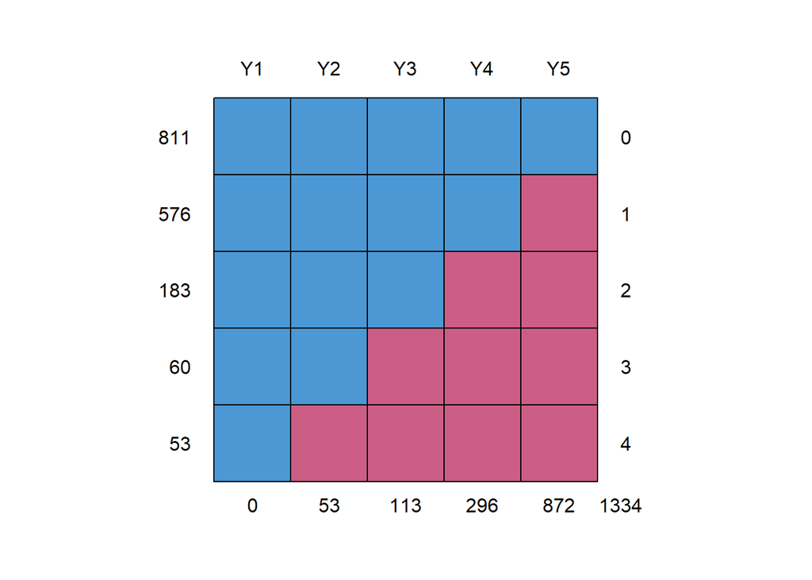

```
##     Y1 Y2  Y3  Y4  Y5
## 811  1  1   1   1   1    0
## 576  1  1   1   1   0    1
## 183  1  1   1   0   0    2
## 60   1  1   0   0   0    3
## 53   1  0   0   0   0    4
##      0 53 113 296 872 1334
```

```r
mice::md.pattern()
```

- Monotone missing data pattern
- 811 people have complete responses
- 53 people dropped out after the first visit
- 60 people dropped out after the second visit
- 183 people dropped out after the third visit
- 576 people dropped out after the fourth visit

**Intermittent (non-monotone) missing data pattern**

- Missing data pattern that is not monotone

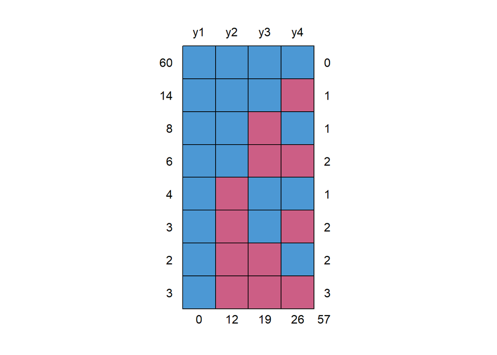

```
##    y1 y2 y3 y4
## 60  1  1  1  1  0
## 14  1  1  1  0  1
## 8   1  1  0  1  1
## 6   1  1  0  0  2
## 4   1  0  1  1  1
## 3   1  0  1  0  2
## 2   1  0  0  1  2
## 3   1  0  0  0  3
##     0 12 19 26 57
```

- Non-monotone missing data pattern
- 60 subjects have complete responses
- 3 subjects have only the baseline response

## Approaches for missing data in longitudinal studies

### Ignorable missingness (MCAR and MAR)

- **Complete-case analysis**
  - Restrict analysis to individuals with no missing data
  - Valid if data are MCAR
- **Available data analysis**
  - Use all available data (include individuals with some missing data)
  - Valid if data are MCAR
- **Last value carried forward**
  - Applies to monotone missing data
  - Use last observed observation for subsequent missing observations
  - Still popular despite many disadvantages
  - Produces biased estimates and small standard errors
- **Maximum likelihood methods**
  - Maximum likelihood methods (linear mixed effects models, generalized linear mixed effects models) are valid if data are MCAR/MAR
  - Requires the correct specification of the mean and variance model
- **Inverse probability weighting**
  - Weighting method that attempts to “even out” the contribution by individuals
  - Appropriate for monotone missing data pattern
  - Works well with marginal models (generalized estimating equations or GEE)
  - Valid if data are MCAR/MAR
- **Multiple imputation**
  - Appropriate for monotone and intermittent missing patterns
- Other methods include
  - Combination of IPW and MI
  - EM algorithm
  - Bayesian methods
  - [Many R packages are available](https://cran.r-project.org/web/views/MissingData.html)

## Inverse probability weighting

### Overview

- Basic idea is to estimate the probability of individuals remaining (or dropping out) in the study and weigh each observation according to that probability
  - Individuals with low probability of remaining in the study (high probability of dropping out) are given larger weights
  - Individuals with high probability of remaining in the study (low probability of dropping out) are given smaller weights
- IPW methods are more straightforward to implement with **monotone** missing data pattern
- IPW methods are more appealing when a full likelihood-based analysis is not possible
  - i.e. marginal analysis with discrete responses
  - IPW is often incorporated into **GEE**
- Requires the correct specification of the dropout model ($\Pr(R_{ij}=1|R_{i1}=\cdots R_{i,j-1}, X_{i}, Y_{i1},...,Y_{i,j-1})$)

### IPW-GEE

The IPW-GEE estimator is obtained as the solution to the following **weighted** estimating equations:

$$\sum_{i=1}^{N}D_{i}^{T}V_{i}^{-1}W_{i}(Y_{i}-\mu)=0,$$
where

- $D_{i}$ is the $n \times p$ derivative matrix
- $V_{i}$ is a $n \times n$ working covariance matrix for $Y_{i}$
- $W_{i}$ is a $n \times n$ **diagonal** matrix of the occasion-specific weights, $w_{ij}$, for $j = 1,...,n$,
  $$W_{i}=
  \left(\begin{array}{cccc}
  R_{i1}\times w_{i1} & 0 & ... & 0\\
  0 & R_{i2}\times w_{i2} & ... & 0\\
  \vdots & \vdots & \ddots & \vdots \\
  0 & 0 & ... & R_{in}\times w_{in}
  \end{array}\right)$$

The weight, $w_{ij}$ is the inverse of the **unconditional** probability of being observed at the $j$th occasion.

To calculate these weights, let $\pi_{ij}$ denote the **conditional** probability of the $i$th individual being observed (or not dropping out) at the $j$th occasion, given that this individual was observed at the prior occasions.

For the first occasion we usually assume $R_{i1}=1$ for all individuals, and then $\pi_{i1}=1$.

The MAR assumption implies that
$$\pi_{ij}=\Pr(R_{ij}=1|R_{i1}= \cdots = R_{i,j-1}=1, Y_{i1}= \cdots =
Y_{i,j-1}, X_{i}).$$

The **unconditional** probability of being observed at the $j$th occasion can be expressed as the **cumulative product** of the **conditional** probabilities,
$$\pi_{i1} \times \pi_{i2} \times \cdots \times \pi_{ij}.$$
The required weight is then given by the **inverse** of the cumulative product of conditional probabilities,
$$w_{ij} = (\pi_{i1} \times \pi_{i2} \times \cdots \times \pi_{ij})^{-1}.$$

### Estimation of weights

We can estimate $\pi_{ij}$ by constructing a logistic regression model for $\pi_{ij}$:

$$\begin{aligned}
\text{logit}(\pi_{ij}) &=
\text{logit}\left\{\Pr(R_{ij}=1|R_{i1}=\cdots=R_{i,j-1}=1,Z_{ij})\right\}\\
&= Z_{ij}^{T}\theta
\end{aligned}$$
where $Z_{ij}$ is a $q \times 1$ design vector that incorporates:

- certain components of $X_{ij}$
- past responses ($Y_{i1},...,Y_{i,j-1}$)
- possibly additional covariates that may be predictive of dropout but are not of subject-matter interest in the marginal model for the mean response

### Assumptions

- The missing data mechanism depends only on **variables fully observed** in the sample
- The probability of being observed ($\pi_{ij}$) is **positive** (not close to zero)
  - If $\pi_{ij}$ is very small, $w_{ij}$ will be extremely large
  - Extremely large weights on small subset of observations may yield regression parameter estimates that are unstable and have poor precision
- Safest to assume working **independence** correlation
  - Need robust standard errors using the sandwich variance estimator

### Detailed approach with data from skin cancer study

We are interested in modeling the population-averaged inference of the change in risk of new skin cancer by treatment group

$$\text{logit}(\mu_{ij})=\beta_{0} + \beta_{1}\text{Year}_{ij} +
\beta_{2}\text{Year}^{2}_{ij} + \beta_{4}\text{Treatment}_{i} +
\beta_{5}(\text{Year}_{ij} \times \text{Treatment}_{i})+
\beta_{6}(\text{Year}^{2}_{ij} \times \text{Treatment}_{i})$$

- Because we are interested in modeling the marginal probability of a **discrete** (or more specifically, binary) outcome, we cannot employ ML methods
- We need to fit a marginal model using GEE
  - Estimates will be biased if data are MAR
- Incorporate IPW

### Model for dropout process

- First, we will fit a model for the dropout process
- The outcome is $\text{logit}(\pi_{ij}) = \text{logit}\left\{\Pr(R_{ij}=1)\right\}$
  - Although it is called the “dropout model”, we are modeling the probability of **not** dropping out
  - We don’t include baseline data (everybody is observed)
- The predictors include fully observed covariates and previously observed responses
  $$\begin{aligned}
  \text{logit}(\pi_{ij})&=\theta_{1}+\theta_{2}I(t=3)+\theta_{3}I(t=4)+\theta_{4}I(t=5)+\theta_{5}\text{age}_{i}+\theta_{6}\text{skin}_{i}+\theta_{7}\text{treatment}_{i}\\
  &+\theta_{8}\text{gender}_{i}+\theta_{9}\text{exposure}_{i}+\theta_{10}Y_{i,j-1}+\theta_{11}(\text{treatment}_{i}\times
  Y_{i,j-1}), \quad j = 2,3,4,5
  \end{aligned}$$
  where $\pi_{ij}=\Pr(R_{ij}=1|R_{i1}= \cdots = R_{i,j-1}=1, Y_{i,j-1}, X_{i})$.

```r
# change to wide format first to fill in missing years with NA
skin_wide <- skin_data %>%
  pivot_wider(names_from = year,
              names_prefix = "Y",
              values_from = Y_bin)
head(skin_wide)
```

| ID | center | age | skin | gender | exposure | treatment | Y1 | Y2 | Y3 | Y4 | Y5 |
| --- | --- | --- | --- | --- | --- | --- | --- | --- | --- | --- | --- |
| 100034 | 1 | 51 | 1 | 1 | 4 | 0 | 0 | 1 | 1 | 1 | 0 |
| 100045 | 1 | 68 | 1 | 0 | 2 | 0 | 0 | 0 | 0 | 0 | 0 |
| 100056 | 1 | 58 | 1 | 0 | 7 | 0 | 1 | 1 | 0 | 1 | 0 |
| 100067 | 1 | 53 | 1 | 1 | 3 | 0 | 0 | 0 | 0 | 0 | 0 |
| 100102 | 1 | 55 | 0 | 0 | 2 | 0 | 0 | 0 | 0 | 0 | NA |
| 100113 | 1 | 59 | 1 | 1 | 10 | 0 | 0 | 0 | 1 | 0 | 1 |

```r
skin_long <- skin_wide %>%
  pivot_longer(cols = starts_with("Y"),
               values_to = "Y",
               names_to = "Year",
               names_prefix = "Y") %>%
  mutate(Year = as.numeric(as.factor(Year)),
         Year2 = Year^2,
         trtYear = treatment * Year,
         trtYear2 = treatment * Year2)
head(skin_long)
```

| ID | center | age | skin | gender | exposure | treatment | Year | Y | Year2 | trtYear | trtYear2 |
| --- | --- | --- | --- | --- | --- | --- | --- | --- | --- | --- | --- |
| 100034 | 1 | 51 | 1 | 1 | 4 | 0 | 1 | 0 | 1 | 0 | 0 |
| 100034 | 1 | 51 | 1 | 1 | 4 | 0 | 2 | 1 | 4 | 0 | 0 |
| 100034 | 1 | 51 | 1 | 1 | 4 | 0 | 3 | 1 | 9 | 0 | 0 |
| 100034 | 1 | 51 | 1 | 1 | 4 | 0 | 4 | 1 | 16 | 0 | 0 |
| 100034 | 1 | 51 | 1 | 1 | 4 | 0 | 5 | 0 | 25 | 0 | 0 |
| 100045 | 1 | 68 | 1 | 0 | 2 | 0 | 1 | 0 | 1 | 0 | 0 |

```r
ipwdat <- skin_long %>%
  group_by(ID) %>%
  mutate(prevy = dplyr::lag(Y)) %>%
  ungroup() %>%
  mutate(r = ifelse(is.na(Y), 0, 1),
         t2 = ifelse(Year == 2, 1, 0),
         t3 = ifelse(Year == 3, 1, 0),
         t4 = ifelse(Year == 4, 1, 0),
         t5 = ifelse(Year == 5, 1, 0),
         ## ‘*’ not meaningful for factors
         trt.prevy =  as.numeric(as.character(treatment)) * as.numeric(as.character(prevy))) %>%
  filter(!is.na(Y)|!is.na(prevy))
head(ipwdat)
```

| ID | center | age | skin | gender | exposure | treatment | Year | Y | Year2 | trtYear | trtYear2 | prevy | r | t2 | t3 | t4 | t5 | trt.prevy |
| --- | --- | --- | --- | --- | --- | --- | --- | --- | --- | --- | --- | --- | --- | --- | --- | --- | --- | --- |
| 100034 | 1 | 51 | 1 | 1 | 4 | 0 | 1 | 0 | 1 | 0 | 0 | NA | 1 | 0 | 0 | 0 | 0 | NA |
| 100034 | 1 | 51 | 1 | 1 | 4 | 0 | 2 | 1 | 4 | 0 | 0 | 0 | 1 | 1 | 0 | 0 | 0 | 0 |
| 100034 | 1 | 51 | 1 | 1 | 4 | 0 | 3 | 1 | 9 | 0 | 0 | 1 | 1 | 0 | 1 | 0 | 0 | 0 |
| 100034 | 1 | 51 | 1 | 1 | 4 | 0 | 4 | 1 | 16 | 0 | 0 | 1 | 1 | 0 | 0 | 1 | 0 | 0 |
| 100034 | 1 | 51 | 1 | 1 | 4 | 0 | 5 | 0 | 25 | 0 | 0 | 1 | 1 | 0 | 0 | 0 | 1 | 0 |
| 100045 | 1 | 68 | 1 | 0 | 2 | 0 | 1 | 0 | 1 | 0 | 0 | NA | 1 | 0 | 0 | 0 | 0 | NA |

```r
# fit drop-out model
rmod <- glm(r ~ t3 + t4 + t5 + age + skin + treatment + gender + exposure + prevy + trt.prevy,
            data = ipwdat, family = binomial("logit"))
round(summary(rmod)$coef,2)
```

```
##             Estimate Std. Error z value Pr(>|z|)
## (Intercept)     3.77       0.31   12.13     0.00
## t3             -0.16       0.19   -0.85     0.39
## t4             -1.41       0.16   -8.82     0.00
## t5             -3.11       0.15  -20.68     0.00
## age             0.00       0.00    0.06     0.95
## skin           -0.15       0.08   -1.84     0.07
## treatment      -0.14       0.09   -1.59     0.11
## gender         -0.22       0.09   -2.41     0.02
## exposure        0.00       0.01   -0.13     0.90
## prevy          -0.16       0.16   -0.97     0.33
## trt.prevy      -0.20       0.21   -0.95     0.34
```

### Compute IPW

- First, compute the predicted $\text{logit}(\hat\pi_{ij})$ from the dropout model
- Then, compute the predicted $\hat\pi_{ij}$
- Because the first response was fully observed, with $R_{ij}=1$ for all individuals, $\hat\pi_{i1} = 1$ by definition

$$\hat\pi_{ij} =
\frac{\text{exp}(Z_{ij}^{T}\hat\theta)}{1+\text{exp}(Z_{ij}^{T}\hat\theta)}$$

```r
dropcoef <- summary(rmod)$coef[,1]
## create the dataset for predicting the weight
xmat <- model.matrix(~ t3 + t4 + t5 + age + skin + treatment + gender + exposure + prevy + trt.prevy,
                     model.frame(~., data = ipwdat, na.action = na.pass))
dim(xmat)
```

```
## [1] 7953   11
```

```r
ipwdat <- ipwdat %>%
          mutate(logitp = as.numeric(xmat %*% dropcoef),
                 phat = ifelse(Year == 1, 1, exp(logitp)/(1 + exp(logitp)))) %>%
          group_by(ID) %>%
          mutate(cumprob = cumprod(phat),
          ipw = 1/cumprob) %>%
          ungroup()

ipwdat %>%
  filter(ID %in% c(100034, 100067, 103059, 416964)) %>%
  dplyr::select(ID, treatment, Year, Y, prevy, r, logitp, phat, cumprob, ipw) %>%
  print()
```

```
## # A tibble: 20 x 10
##        ID treatment  Year     Y prevy     r logitp  phat cumprob   ipw
##     <int>     <int> <dbl> <dbl> <dbl> <dbl>  <dbl> <dbl>   <dbl> <dbl>
##  1 100034         0     1     0    NA     1 NA     1       1      1
##  2 100034         0     2     1     0     1  3.41  0.968   0.968  1.03
##  3 100034         0     3     1     1     1  3.09  0.956   0.926  1.08
##  4 100034         0     4     1     1     1  1.83  0.862   0.798  1.25
##  5 100034         0     5     0     1     1  0.141 0.535   0.427  2.34
##  6 100067         0     1     0    NA     1 NA     1       1      1
##  7 100067         0     2     0     0     1  3.41  0.968   0.968  1.03
##  8 100067         0     3     0     0     1  3.25  0.963   0.932  1.07
##  9 100067         0     4     0     0     1  2.00  0.880   0.820  1.22
## 10 100067         0     5     0     0     1  0.303 0.575   0.472  2.12
## 11 103059         0     1     0    NA     1 NA     1       1      1
## 12 103059         0     2     0     0     1  3.42  0.968   0.968  1.03
## 13 103059         0     3     0     0     1  3.25  0.963   0.932  1.07
## 14 103059         0     4     0     0     1  2.00  0.881   0.821  1.22
## 15 103059         0     5     0     0     1  0.309 0.577   0.474  2.11
## 16 416964         0     1     0    NA     1 NA     1       1      1
## 17 416964         0     2     0     0     1  3.57  0.973   0.973  1.03
## 18 416964         0     3     0     0     1  3.41  0.968   0.941  1.06
## 19 416964         0     4     0     0     1  2.16  0.896   0.844  1.19
## 20 416964         0     5    NA     0     0  0.462 0.614   0.518  1.93
```

- Prior to conducting an IPW-GEE analysis, we should examine the **distribution** of the estimated weights for any presence of discernibly large weights

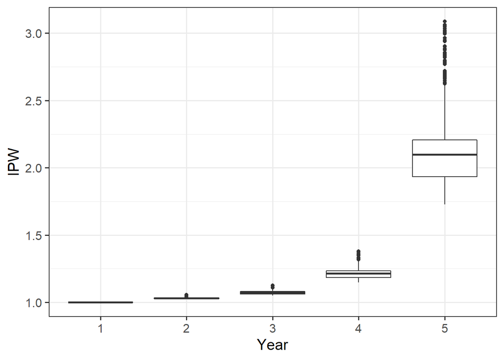

```r
# examine the weights by time point
ipwdat %>%
    ggplot(aes(y = ipw, x = as.factor(Year))) +
    geom_boxplot() +
    labs(y = "IPW", x = "Year")
```

Observations

- $\hat w_{i1}=1$ for all individuals, as should be
- Estimated weights are increasing over time
- Estimated weights range from 1.0 to 3.1 $\rightarrow$ no concern that a small subset of the observations might have undue influence on the analysis

### Model for response with IPW

Finally, we will fit a logistic regression model for the marginal probability of developing skin cancer:

- Use `wights=` option in `geeglm` from R package `geepack`
- To ensure that the weights are appropriately incorporated, we need to make the **“working independence”** assumption for the within-subject association among the responses
- Because a “working independence” assumption is made, standard errors are based on the **sandwich variance** estimator
  - Default for `geeglm`

```r
# ipw-gee
library(geepack)
ipwgee <- geeglm(Y ~ treatment + Year + Year2 + trtYear + trtYear2,
                 family=binomial("logit"),
                 id = ID, scale.fix = TRUE,
                 corstr = "independence",
                 weights = ipw,
                 data = ipwdat)
summary(ipwgee)
```

```
##
## Call:
## geeglm(formula = Y ~ treatment + Year + Year2 + trtYear + trtYear2,
##     family = binomial("logit"), data = ipwdat, weights = ipw,
##     id = ID, corstr = "independence", scale.fix = TRUE)
##
##  Coefficients:
##              Estimate   Std.err   Wald Pr(>|W|)
## (Intercept) -1.374470  0.186246 54.462 1.58e-13 ***
## treatment    0.003619  0.260712  0.000   0.9889
## Year        -0.244271  0.146087  2.796   0.0945 .
## Year2        0.040117  0.025367  2.501   0.1138
## trtYear      0.051900  0.206521  0.063   0.8016
## trtYear2    -0.002670  0.036047  0.005   0.9410
## ---
## Signif. codes:  0 '***' 0.001 '**' 0.01 '*' 0.05 '.' 0.1 ' ' 1
##
## Correlation structure = independence
## Scale is fixed.
##
## Number of clusters:   1683  Maximum cluster size: 5
```

- We will compare **four** different analyses
  - Complete-case analysis
  - Available data analysis
  - Last observation carried forward
  - IPW

```r
# complete cases (remove all subjects who dropout)
ccdat <- skin_long %>%
  group_by(ID) %>%
  mutate(dropout = ifelse(is.na(mean(Y)), 1, 0)) %>%
  ungroup() %>%
  filter(dropout == 0)

ccgee <- geeglm(Y ~ treatment + Year + Year2 + trtYear + trtYear2,
         family = binomial("logit"),
         id = ID, scale.fix = TRUE,
         corstr = "unstructured",
         data = ccdat)


# available data
avdat <- skin_long %>%
  drop_na()
avgee <- geeglm(Y ~ treatment + Year + Year2 + trtYear + trtYear2,
                family = binomial("logit"),
                id = ID, scale.fix = TRUE,
                corstr = "unstructured",
                data = avdat)


# last value carried forward
lvcfdat <- skin_long %>%
  group_by(ID) %>%
  fill(Y) %>%
  ungroup()
lvcfgee <- geeglm(Y ~ treatment + Year + Year2 + trtYear + trtYear2,
                  family = binomial("logit"),
                  id = ID, scale.fix = TRUE,
                  corstr = "unstructured",
                  data = lvcfdat)
```

Estimated regression coefficients (standard errors) from logistic regression analysis

[output not shown]

### Summary

- IPW is useful if only the response variables are missing due to dropout
- IPW requires correct specification of the dropout model for valid estimation of $\beta$
- In the presence of discernibly large weights,
  - Check the sensitivity of results to the inclusion of observations that receive large weights
  - If the analysis results are sensitive to a small number of large weights, then
    - apply weight truncation
    - or consider an alternative methods of adjusting for missingness